# Dimension Reduction

Yuting Sun

```r
#Load required libraries
library(readr)
library(tidyverse)
```

```r
library(stopwords)
library(wordcloud)
library(FactoMineR)
library(factoextra)
```

## Task 1 Build the shape table

```r
#load the dataset
ufo <- read.csv("data/nuforc_sightings.csv")
```

```r
#Check country variations starting with 'U'
ufo %>%
  filter(startsWith(country, "U")) %>%
  count(country, sort = TRUE)
```

```
##                 country      n
## 1                   USA 138705
## 2        United Kingdom   3805
## 3           Unspecified    139
## 4               Ukraine     35
## 5  United Arab Emirates     34
## 6               Uruguay     12
## 7            Uzbekistan      7
## 8                   Usa      5
## 9   U.S. Virgin Islands      3
## 10               Uganda      2
## 11                  UAE      1
## 12      Unioted Kingdom      1
## 13 United Arad Emirates      1
## 14       United Kingdon      1
## 15       United kingdom      1
## 16              Unknown      1
## 17       Unuted Kingdom      1
```

Multiple entries for “USA” (e.g., “Usa”, “usa”) indicate data cleaning is needed.

```r
#Clean and standardize country data
ufo %>%
  mutate(country_upper = toupper(trimws(country))) %>%
  filter(grepl("US|AMERICA|STATES|UNITED STATES|U.S.", country_upper)) %>%
  count(country, sort = TRUE)
```

```
##                                      country      n
## 1                                        USA 138705
## 2                                  Australia   1060
## 3                                Unspecified    139
## 4                                     Russia     56
## 5                                     Cyprus     49
## 6                                    Austria     26
## 7                                  Mauritius      9
## 8                                        Usa      5
## 9                             American Samoa      3
## 10                       U.S. Virgin Islands      3
## 11                                   Belarus      2
## 12                                       usa      2
## 13                               Bahamas/USA      1
## 14                               Cruise ship      1
## 15            Federated States of Micronesia      1
## 16                     Guyana, South America      1
## 17                          Mauritius Island      1
## 18                           Northern Cyprus      1
## 19                                     Orust      1
## 20              San Juan and St. Thomas USVI      1
## 21                          Slovakia/Austria      1
## 22 South Atlantic/Caribbean (on cruise ship)      1
## 23                         Western Australia      1
## 24                        over New Brunswick      1
```

Should excluded ambiguous entries like “Bahamas/USA” to focus on mainland USA. also excluded U.S. Virgin Islands.

```r
#Verify no missing country values
sum(is.na(ufo$country))
```

```
## [1] 0
```

```r
#check missing values of state in the USA
usa_no_state <- ufo %>%
  filter((country == "USA" | country == "US") & (is.na(state) | state == "" | state == "Unkown"))

nrow(usa_no_state)
```

```
## [1] 0
```

```r
# Filter for USA and check state completeness
ufo_us <- ufo %>%
  mutate(
    country = toupper(trimws(country))
  ) %>%

  filter(country == "USA")
```

```r
# Filter for USA and check state completeness
ufo_us %>%
  count(country, sort = TRUE)
```

```
##   country      n
## 1     USA 138712
```

```r
# Clean and summarize state data
ufo_us %>%
  count(state, sort = TRUE) %>%
  head(100)
```

```
##            state     n
## 1             CA 16905
## 2             FL  8709
## 3             WA  7507
## 4             TX  6548
## 5             NY  6223
## 6             PA  5288
## 7             AZ  5265
## 8             OH  4647
## 9             IL  4443
## 10            NC  3848
## 11            MI  3833
## 12            OR  3731
## 13            CO  3488
## 14            NJ  3036
```

[output cut: 54 more lines]

some enteies’ state is not USA’s state, and some did not use abbreviation, etc

```r
#Define valid U.S. states
us_states <- c("AL", "AK", "AZ", "AR", "CA", "CO", "CT", "DE", "FL", "GA",
               "HI", "ID", "IL", "IN", "IA", "KS", "KY", "LA", "ME", "MD",
               "MA", "MI", "MN", "MS", "MO", "MT", "NE", "NV", "NH", "NJ",
               "NM", "NY", "NC", "ND", "OH", "OK", "OR", "PA", "RI", "SC",
               "SD", "TN", "TX", "UT", "VT", "VA", "WA", "WV", "WI", "WY",
               "DC")
#Create state mapping (abbreviation to full name)
state_mapping <- data.frame(
  abbreviation = c("AL", "AK", "AZ", "AR", "CA", "CO", "CT", "DE", "FL", "GA",
                   "HI", "ID", "IL", "IN", "IA", "KS", "KY", "LA", "ME", "MD",
                   "MA", "MI", "MN", "MS", "MO", "MT", "NE", "NV", "NH", "NJ",
                   "NM", "NY", "NC", "ND", "OH", "OK", "OR", "PA", "RI", "SC",
                   "SD", "TN", "TX", "UT", "VT", "VA", "WA", "WV", "WI", "WY", "DC"),
  full_name = c("Alabama", "Alaska", "Arizona", "Arkansas", "California",
                "Colorado", "Connecticut", "Delaware", "Florida", "Georgia",
                "Hawaii", "Idaho", "Illinois", "Indiana", "Iowa", "Kansas",
                "Kentucky", "Louisiana", "Maine", "Maryland", "Massachusetts",
                "Michigan", "Minnesota", "Mississippi", "Missouri", "Montana",
                "Nebraska", "Nevada", "New Hampshire", "New Jersey", "New Mexico",
                "New York", "North Carolina", "North Dakota", "Ohio", "Oklahoma",
                "Oregon", "Pennsylvania", "Rhode Island", "South Carolina",
                "South Dakota", "Tennessee", "Texas", "Utah", "Vermont",
                "Virginia", "Washington", "West Virginia", "Wisconsin", "Wyoming",
                "District of Columbia")
)
```

```r
# unique state in ufo_us
all_states_in_data <- unique(ufo_us$state)

# match with state_mapping
non_us_states <- all_states_in_data[!all_states_in_data %in% us_states]

print("not US states：")
```

```
## [1] "not US states："
```

```r
print(non_us_states)
```

```
##  [1] "England"       "Montana"       "Wisconsin"     "Ohio"
##  [5] "VI"            "New York"      "Corrientes"    "-"
##  [9] "0"             "PR"            "ENG"           "Fl"
## [13] "West Virginia" "NB"            "GU"            "Ca"
## [17] "UM"
```

```r
ufo_us %>%
  filter(state %in% non_us_states) %>%
  count(state, sort = TRUE)
```

```
##            state   n
## 1             PR 192
## 2              - 116
## 3             VI  20
## 4             Fl   5
## 5             GU   3
## 6              0   1
## 7             Ca   1
## 8     Corrientes   1
## 9            ENG   1
## 10       England   1
## 11       Montana   1
## 12            NB   1
## 13      New York   1
## 14          Ohio   1
## 15            UM   1
## 16 West Virginia   1
## 17     Wisconsin   1
```

```r
# Clean state data
ufo_us_clean <- ufo_us %>%
  mutate(
    # tolower
    state = trimws(tolower(state)),

    # transfer
    state = case_when(
      state == "montana" ~ "MT",
      state == "new york" ~ "NY",
      state == "ohio" ~ "OH",
      state == "west virginia" ~ "WV",
      state == "wisconsin" ~ "WI",
      TRUE ~ toupper(state)
    )
  ) %>%
  # filter states not in the US
  filter(state %in% us_states)

#
print(paste("state count:", length(unique(ufo_us_clean$state))))
```

```
## [1] "state count: 51"
```

```r
# checking states
unique(ufo_us_clean$state) %>% sort()
```

```
##  [1] "AK" "AL" "AR" "AZ" "CA" "CO" "CT" "DC" "DE" "FL" "GA" "HI" "IA" "ID" "IL"
## [16] "IN" "KS" "KY" "LA" "MA" "MD" "ME" "MI" "MN" "MO" "MS" "MT" "NC" "ND" "NE"
## [31] "NH" "NJ" "NM" "NV" "NY" "OH" "OK" "OR" "PA" "RI" "SC" "SD" "TN" "TX" "UT"
## [46] "VA" "VT" "WA" "WI" "WV" "WY"
```

```r
# data quality of shape
unique(ufo_us_clean$shape)
```

```
##  [1] "Unknown"   "Orb"       "Changing"  "Oval"      "Sphere"    "Light"
##  [7] "Triangle"  "Formation" "Circle"    "Cigar"     "Cube"      "Rectangle"
## [13] "Disk"      "Cross"     "Star"      "Other"     "Fireball"  "Cylinder"
## [19] "Flash"     "Teardrop"  "Diamond"   "Cone"      "Chevron"   "Egg"
## [25] ""          "rectangle" "light"     "other"     "fireball"  "triangle"
## [31] "circle"    "cylinder"  "unknown"   "cigar"     "sphere"    "oval"
## [37] "egg"       "diamond"   "flash"     "changing"
```

```r
ufo_us_clean %>%
  count(shape, sort = TRUE)
```

```
##        shape     n
## 1      Light 25334
## 2     Circle 13445
## 3   Triangle 12344
## 4    Unknown  9374
## 5      Other  9182
## 6   Fireball  9105
## 7       Disk  7874
## 8     Sphere  7006
## 9        Orb  6535
## 10      Oval  5884
## 11            5773
## 12 Formation  4536
## 13  Changing  3931
## 14     Cigar  3512
```

[output cut: 26 more lines]

```r
# Is there NA, Null, trimming spaces/white space in shape column
sum(is.na(ufo_us_clean$shape))
```

```
## [1] 0
```

```r
sum(ufo_us_clean$shape == "", na.rm = TRUE)
```

```
## [1] 5773
```

```r
head(ufo_us_clean$shape, 20)
```

```
##  [1] "Unknown"   "Orb"       "Unknown"   "Changing"  "Oval"      "Sphere"
##  [7] "Changing"  "Light"     "Triangle"  "Triangle"  "Formation" "Changing"
## [13] "Orb"       "Orb"       "Formation" "Orb"       "Light"     "Triangle"
## [19] "Orb"       "Orb"
```

```r
#Clean shape column
ufo_us_clean_shape <- ufo_us_clean %>%
  mutate(

    shape = tolower(shape),

    shape = trimws(shape),


    shape = case_when(
      is.na(shape) ~ "unknown",
      shape == "" ~ "unknown",
      TRUE ~ shape
    )
  )


ufo_us_clean_shape %>%
  count(shape, sort = TRUE)
```

```
##        shape     n
## 1      light 25389
## 2    unknown 15148
## 3     circle 13453
## 4   triangle 12362
## 5      other  9201
## 6   fireball  9107
## 7       disk  7874
## 8     sphere  7013
## 9        orb  6535
## 10      oval  5886
## 11 formation  4536
## 12  changing  3932
## 13     cigar  3515
## 14 rectangle  2519
## 15  cylinder  2383
## 16     flash  2233
## 17   diamond  1949
## 18   chevron  1684
## 19       egg  1156
## 20  teardrop  1137
## 21      cone   540
## 22     cross   479
## 23      star   258
## 24      cube    86
```

```r
# Create shape-by-state frequency table
shape_by_state <- ufo_us_clean_shape %>%
  count(state, shape) %>%
  pivot_wider(
    names_from = shape,             # shape-column
    values_from = n,                      # count
    values_fill = 0
  )

# Check dimensions and unique states
head(shape_by_state)
```

```
## # A tibble: 6 × 25
##   state changing chevron cigar circle  cone cross cylinder diamond  disk   egg
##   <chr>    <int>   <int> <int>  <int> <int> <int>    <int>   <int> <int> <int>
## 1 AK          15       3    16     71     2     1       13      10    47     2
## 2 AL          40      19    42    156     3     5       35      23    85    20
## 3 AR          33      22    36    132     4     4       29      17    72     8
## 4 AZ         179      56   111    481    30    17       79      68   258    51
## 5 CA         570     255   382   1637    70    62      266     272  1028   161
## 6 CO          97      73    89    303    10    14       64      38   183    28
## # ℹ 14 more variables: fireball <int>, flash <int>, formation <int>,
## #   light <int>, orb <int>, other <int>, oval <int>, rectangle <int>,
## #   sphere <int>, teardrop <int>, triangle <int>, unknown <int>, star <int>,
## #   cube <int>
```

```r
dim(shape_by_state)
```

```
## [1] 51 25
```

```r
unique(shape_by_state$state)
```

```
##  [1] "AK" "AL" "AR" "AZ" "CA" "CO" "CT" "DC" "DE" "FL" "GA" "HI" "IA" "ID" "IL"
## [16] "IN" "KS" "KY" "LA" "MA" "MD" "ME" "MI" "MN" "MO" "MS" "MT" "NC" "ND" "NE"
## [31] "NH" "NJ" "NM" "NV" "NY" "OH" "OK" "OR" "PA" "RI" "SC" "SD" "TN" "TX" "UT"
## [46] "VA" "VT" "WA" "WI" "WV" "WY"
```

```r
# Identify state with most "Circle" sightings
shape_by_state$state[which.max(shape_by_state$circle)]
```

```
## [1] "CA"
```

## Task 2 PCA on the shape table

```r
#convert counts to proporities
shape_matrix <- shape_by_state %>%
  column_to_rownames("state")
state_totals <- rowSums(shape_matrix)
shape_proportions <- shape_matrix / state_totals # Row-normalization
head(rowSums(shape_proportions))
```

```
## AK AL AR AZ CA CO
##  1  1  1  1  1  1
```

```r
#Perform PCA
pca_result <- prcomp(shape_proportions, scale. = TRUE, center = TRUE)

#Summary of PCA results
summary(pca_result)
```

```
## Importance of components:
##                          PC1   PC2    PC3     PC4     PC5     PC6     PC7
## Standard deviation     1.813 1.697 1.6247 1.39757 1.34554 1.22562 1.20175
## Proportion of Variance 0.137 0.120 0.1100 0.08138 0.07544 0.06259 0.06017
## Cumulative Proportion  0.137 0.257 0.3669 0.44834 0.52377 0.58636 0.64654
##                            PC8     PC9    PC10    PC11    PC12   PC13    PC14
## Standard deviation     1.11583 1.06048 0.97831 0.91356 0.82458 0.7668 0.72938
## Proportion of Variance 0.05188 0.04686 0.03988 0.03478 0.02833 0.0245 0.02217
## Cumulative Proportion  0.69842 0.74527 0.78515 0.81993 0.84826 0.8728 0.89492
##                           PC15    PC16    PC17   PC18    PC19    PC20   PC21
## Standard deviation     0.71577 0.65568 0.59065 0.5587 0.50748 0.48645 0.4542
## Proportion of Variance 0.02135 0.01791 0.01454 0.0130 0.01073 0.00986 0.0086
## Cumulative Proportion  0.91627 0.93418 0.94872 0.9617 0.97245 0.98231 0.9909
##                           PC22    PC23      PC24
## Standard deviation     0.34409 0.31586 3.486e-16
## Proportion of Variance 0.00493 0.00416 0.000e+00
## Cumulative Proportion  0.99584 1.00000 1.000e+00
```

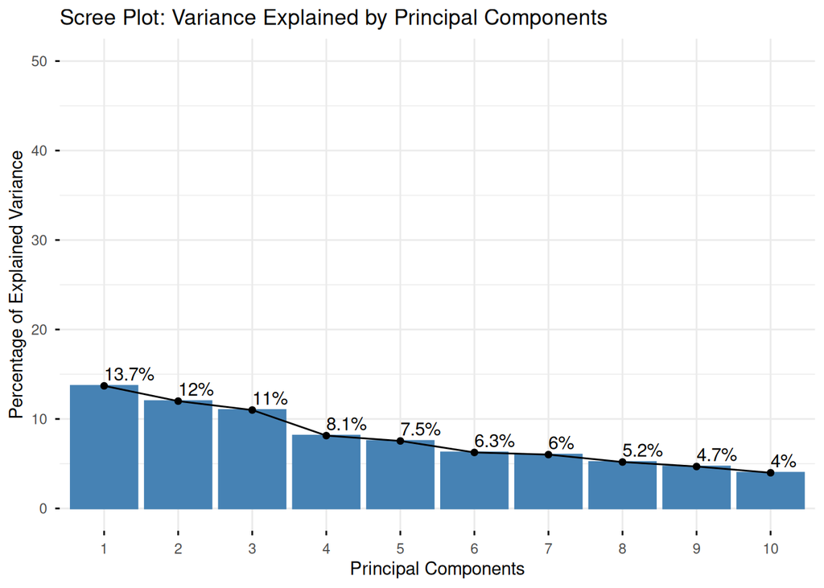

```r
#Create screen plot
fviz_eig(pca_result,
         addlabels = TRUE,
         ylim = c(0, 50),
         main = "Scree Plot: Variance Explained by Principal Components",
         xlab = "Principal Components",
         ylab = "Percentage of Explained Variance")
```

The plot shows that the first few principal components explain a substantial portion of the variance.

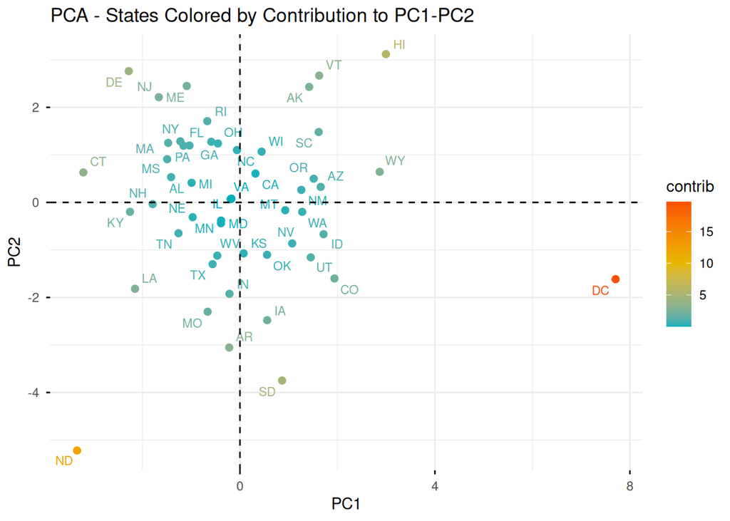

```r
#Create scree plot
fviz_pca_ind(pca_result,
             col.ind = "contrib",
             gradient.cols = c("#00AFBB", "#E7B800", "#FC4E07"),
             repel = TRUE,
             labelsize = 3,
             pointsize = 2,
             title = "PCA - States Colored by Contribution to PC1-PC2",
             xlab = "PC1",
             ylab = "PC2")
```

Based on the scatterplot, there are no visible regional clusters.  
However, the plot clearly shows two significant outliers, DC and ND, which have unique UFO shape distributions compared to all other states.

```r
# Loadings for PC1 and PC2
loadings <- pca_result$rotation[, 1:2]
loadings_df <- as.data.frame(loadings)
loadings_df$shape <- rownames(loadings_df)
```

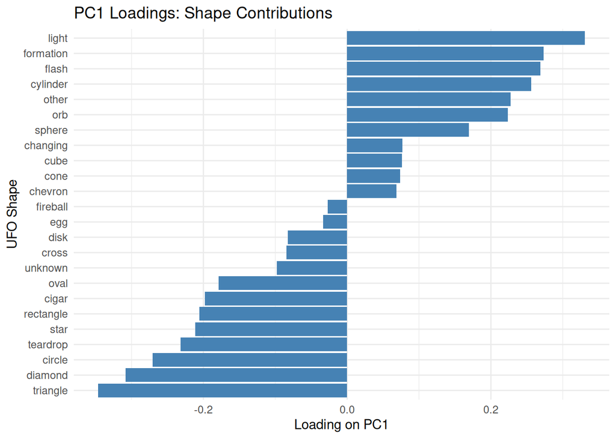

```r
# Bar plots for loadings
ggplot(loadings_df, aes(x = reorder(shape, PC1), y = PC1)) +
  geom_bar(stat = "identity", fill = "steelblue") +
  coord_flip() +
  labs(title = "PC1 Loadings: Shape Contributions",
       x = "UFO Shape",
       y = "Loading on PC1") +
  theme_minimal()
```

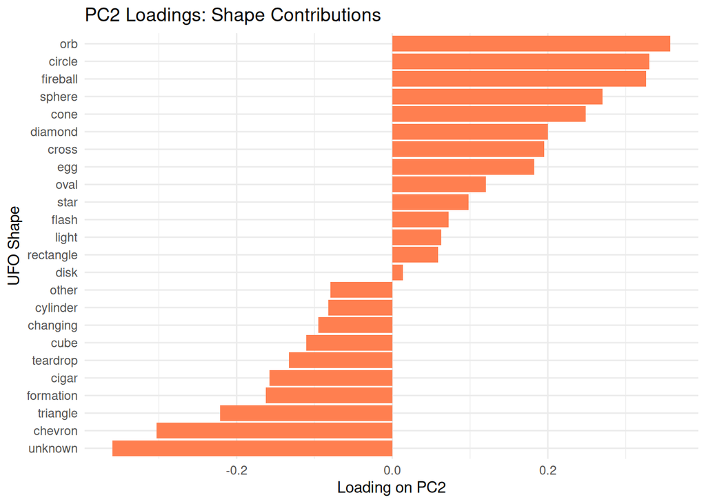

```r
ggplot(loadings_df, aes(x = reorder(shape, PC2), y = PC2)) +
  geom_bar(stat = "identity", fill = "coral") +
  coord_flip() +
  labs(title = "PC2 Loadings: Shape Contributions",
       x = "UFO Shape",
       y = "Loading on PC2") +
  theme_minimal()
```

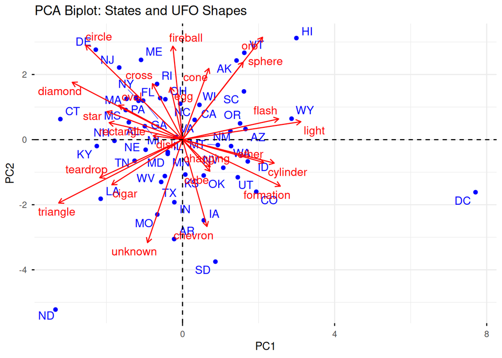

```r
#Biplot
fviz_pca_biplot(pca_result,
                repel = TRUE,
                col.var = "red",
                col.ind = "blue",
                title = "PCA Biplot: States and UFO Shapes",
                xlab = "PC1",
                ylab = "PC2")
```

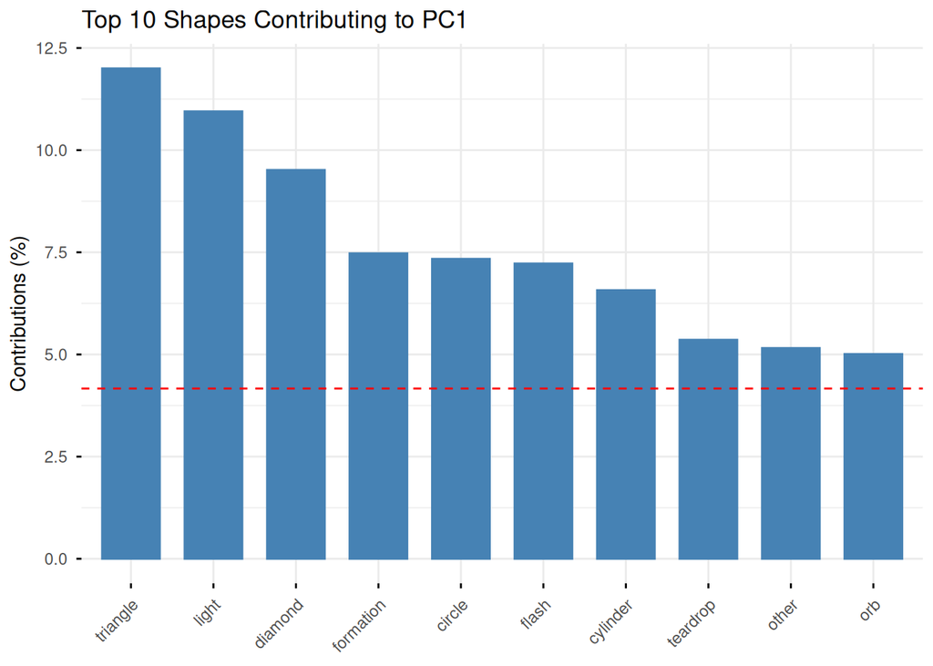

```r
#Contribution plots for PC1
fviz_contrib(pca_result, choice = "var", axes = 1, top = 10,
             title = "Top 10 Shapes Contributing to PC1")
```

Based on the fviz_contrib() bar plot, the shapes that contribute the most to PC1 are:Triangle, Light and Diamond.

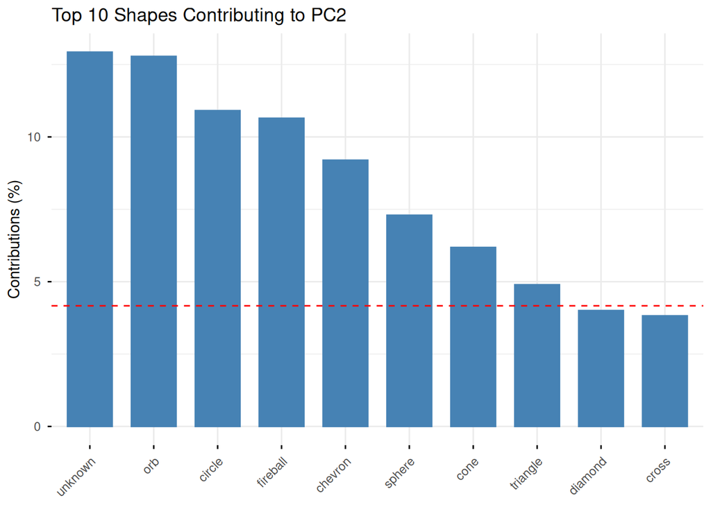

```r
#Contribution plots for PC2
fviz_contrib(pca_result, choice = "var", axes = 2, top = 10,
             title = "Top 10 Shapes Contributing to PC2")
```

## Task 3 Clean and tokenize the summaries

```r
#Clean summary
ufo_us_clean_shape <- ufo_us_clean_shape %>%
  mutate(
    summary_clean = ifelse(is.na(summary) | summary == "", NA, summary),  # Handle NA or empty
    summary_clean = tolower(summary),  # Convert to lowercase
    summary_clean = gsub("[^[ -~]]", "", summary_clean),  # Remove non-ASCII characters
    summary_clean = trimws(summary_clean),  # Trim whitespace from edges
    summary_clean = gsub("\\s+", " ", summary_clean)  # Replace repeated internal whitespace with single space
  )

print(head(ufo_us_clean_shape$summary_clean, 10))  # Debug output
```

```
##  [1] "same craft that i reported about on previous early am"
##  [2] "while camping we watched a group of lights move in an area mostly under the handle of the big dipper."
##  [3] "was out walking dog when i noticed a white blinking light way off in the distance. realized it was moving back and forth"
##  [4] "i saw a black object in the sky hovering and changing shape but it disappeared after 5 minutes"
##  [5] "shooting out of a large cloud, distinct before entering another large cloud. more luminous/reflective than clouds. no trails at all."
##  [6] "two brightly lit spheres"
##  [7] "two strange orb-like lights in the sky above mesa, az. they looked like suspended firecrackers or spider-shaped sparks"
##  [8] "2 bright light unknown in the sky"
##  [9] "while watching perseids, a silent small triangular craft flew over me from sw to ne, then disappeared."
## [10] "small light moving erratically, when lightning strikes it aluminates the shape around the light"
```

```r
    #install.packages("tidytext")
```

```r
# Tokenize the cleaned summaries into words using tidytext
library(tidytext)
tokens <- ufo_us_clean_shape %>%
  unnest_tokens(word, summary_clean)  # Break into array of words

# Generate a table showing the most frequent words (top 20 for brevity)
word_freq <- tokens %>%
  count(word, sort = TRUE)

head(word_freq, 20)
```

```
##      word     n
## 1     the 64732
## 2       a 57445
## 3      in 57397
## 4     and 47612
## 5      of 36279
## 6  lights 31757
## 7       i 30858
## 8   light 30850
## 9     sky 30085
## 10     to 29089
## 11    was 23746
## 12 object 23009
## 13 bright 22993
## 14   over 20609
## 15     it 20462
## 16     at 18952
## 17   with 17365
## 18 moving 16728
## 19     on 16309
## 20  white 15182
```

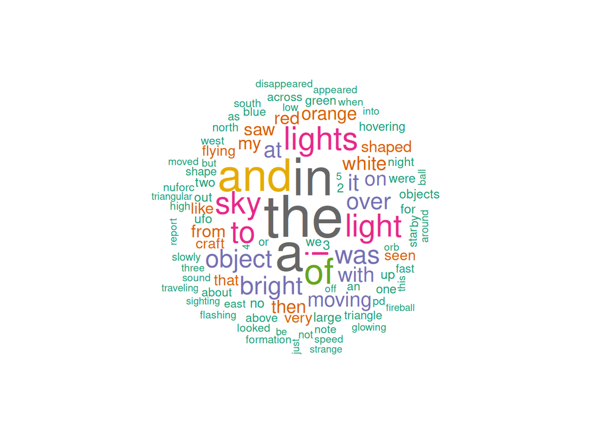

```r
# Create a word cloud
wordcloud(words = word_freq$word[1:100], freq = word_freq$n[1:100],
          min.freq = 100, random.order = FALSE, colors = brewer.pal(8, "Dark2"))
```

In this initial output, the most frequent words are mostly common, such as “the”, “a”, “in”, “and”, “of” etc. These do not provide much insight into the UFO sightings themselves, as they are stopwords that appear in almost any English text.

```r
# Remove stopwords using the stopwords package
stop_words <- stopwords("en")  # Get English stopwords

tokens_no_stop <- tokens %>%
  filter(!word %in% stop_words)  # Remove stopwords

# Re-generate the frequency table (top 20)
word_freq_no_stop <- tokens_no_stop %>%
  count(word, sort = TRUE)

head(word_freq_no_stop, 20)
```

```
##       word     n
## 1   lights 31757
## 2    light 30850
## 3      sky 30085
## 4   object 23009
## 5   bright 22993
## 6   moving 16728
## 7    white 15182
## 8   orange 13973
## 9      red 13596
## 10     saw 13529
## 11  shaped 10963
## 12    like 10585
## 13   craft  9270
## 14  flying  9216
## 15    seen  9184
## 16       3  7476
## 17     ufo  7397
## 18     two  7367
## 19   large  7356
## 20 objects  6866
```

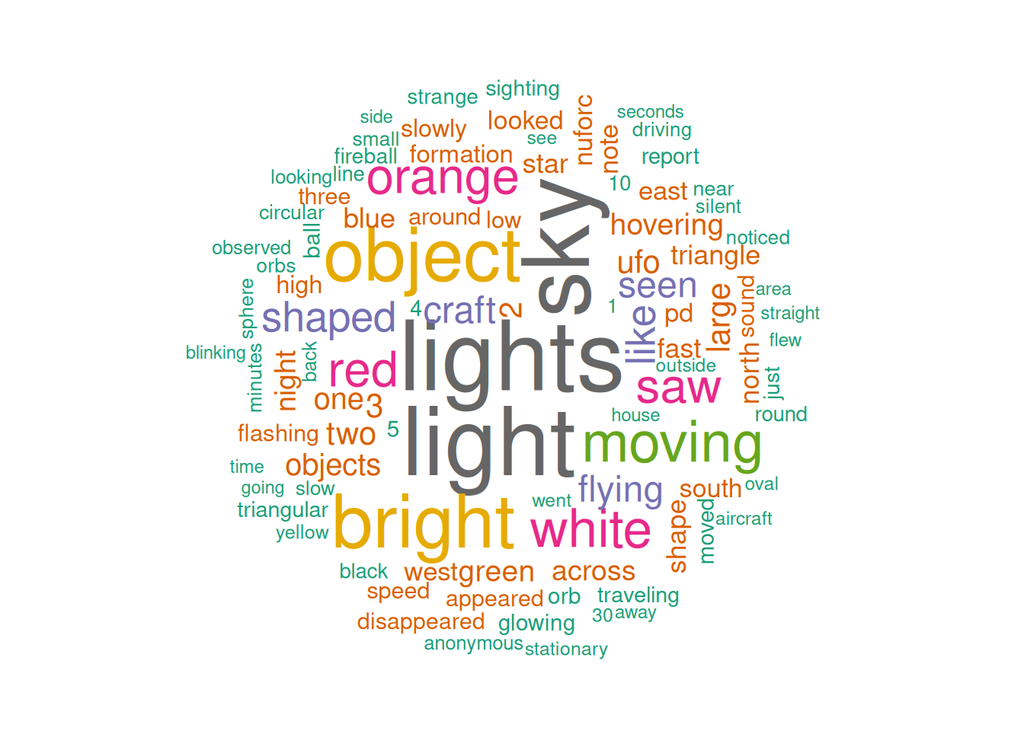

```r
# Re-make the word cloud without stopwords
wordcloud(words = word_freq_no_stop$word[1:100], freq = word_freq_no_stop$n[1:100],
          min.freq = 100, random.order = FALSE, colors = brewer.pal(8, "Dark2"))
```

After stopword removal, the words that feel most characteristic of these reports include terms like “lights”, “light”, “sky”, “object”,“bright”, “moving”, etc. These suggest common themes in descriptions, such as visual appearances (colors, brightness) and behaviors (movement, hovering) of the sighted objects.

## Task 4 Build the keyword table and repeat PCA

```r
# Define a vocabulary of the top 100 most frequent words from cleaned summaries
vocab <- word_freq_no_stop %>%
  filter(nchar(word) >= 3) %>%  # At least 3 characters
  slice(1:100) %>%  # Top 100
  pull(word)
```

```r
# Create a wide table: state-by-keyword counts
# First, filter tokens to only include words in vocab
tokens_vocab <- tokens_no_stop %>%
  filter(word %in% vocab)

# count per state and pivot wider
keyword_by_state <- tokens_vocab %>%
  group_by(state, word) %>%
  summarise(n = n(), .groups = "drop") %>%
  pivot_wider(
    names_from = word,
    values_from = n,
    values_fill = 0
  )
```

```r
#show dimensions and head
dim(keyword_by_state)
```

```
## [1]  51 101
```

```r
head(keyword_by_state)
```

```
## # A tibble: 6 × 101
##   state across aircraft anonymous appeared  area around  away  back  ball black
##   <chr>  <int>    <int>     <int>    <int> <int>  <int> <int> <int> <int> <int>
## 1 AK        26       12        14       20    14     26    18    11    10    18
## 2 AL        68       28        29       62    22     41    25    24    41    29
## 3 AR        46       35        31       39    19     33    22    31    45    29
## 4 AZ       185       95        81      173   129    154    70   130   119   121
## 5 CA       693      294       326      486   329    485   304   281   501   406
## 6 CO       138       62        86       96    68     87    44    54    76    99
## # ℹ 90 more variables: blinking <int>, blue <int>, bright <int>, circle <int>,
## #   circular <int>, color <int>, craft <int>, direction <int>,
## #   disappeared <int>, driving <int>, east <int>, fast <int>, fireball <int>,
## #   first <int>, flashing <int>, flew <int>, flying <int>, formation <int>,
## #   glowing <int>, going <int>, green <int>, high <int>, house <int>,
## #   hovering <int>, just <int>, large <int>, light <int>, lights <int>,
## #   like <int>, line <int>, looked <int>, looking <int>, low <int>, …
```

```r
#PCA
#convert counts to proporities
keyword_matrix <- keyword_by_state %>%
  column_to_rownames("state")
state_totals_keywords <- rowSums(keyword_matrix)
keyword_proportions <- keyword_matrix / state_totals_keywords
head(rowSums(keyword_proportions))
```

```
## AK AL AR AZ CA CO
##  1  1  1  1  1  1
```

```r
# Perform PCA
pca_result_keywords <- prcomp(keyword_proportions, scale. = TRUE, center = TRUE)
summary(pca_result_keywords)
```

```
## Importance of components:
##                           PC1     PC2    PC3     PC4     PC5     PC6     PC7
## Standard deviation     3.5430 2.89295 2.7839 2.54993 2.29010 2.20262 2.14405
## Proportion of Variance 0.1255 0.08369 0.0775 0.06502 0.05245 0.04852 0.04597
## Cumulative Proportion  0.1255 0.20922 0.2867 0.35174 0.40419 0.45270 0.49867
##                            PC8     PC9    PC10    PC11    PC12    PC13    PC14
## Standard deviation     2.11973 1.88800 1.86419 1.74596 1.65956 1.62010 1.54997
## Proportion of Variance 0.04493 0.03565 0.03475 0.03048 0.02754 0.02625 0.02402
## Cumulative Proportion  0.54361 0.57925 0.61400 0.64449 0.67203 0.69827 0.72230
##                           PC15    PC16   PC17    PC18    PC19   PC20    PC21
## Standard deviation     1.49773 1.48755 1.4176 1.34510 1.27168 1.2206 1.18267
## Proportion of Variance 0.02243 0.02213 0.0201 0.01809 0.01617 0.0149 0.01399
## Cumulative Proportion  0.74473 0.76686 0.7870 0.80505 0.82122 0.8361 0.85011
##                           PC22    PC23    PC24    PC25   PC26    PC27    PC28
## Standard deviation     1.13651 1.12397 1.03178 1.01847 1.0000 0.97226 0.90213
## Proportion of Variance 0.01292 0.01263 0.01065 0.01037 0.0100 0.00945 0.00814
## Cumulative Proportion  0.86302 0.87566 0.88630 0.89667 0.9067 0.91613 0.92427
##                           PC29    PC30   PC31    PC32    PC33    PC34    PC35
## Standard deviation     0.86212 0.84344 0.8000 0.79200 0.74315 0.71957 0.66018
## Proportion of Variance 0.00743 0.00711 0.0064 0.00627 0.00552 0.00518 0.00436
## Cumulative Proportion  0.93170 0.93881 0.9452 0.95149 0.95701 0.96219 0.96654
##                           PC36    PC37    PC38    PC39    PC40    PC41    PC42
## Standard deviation     0.64599 0.61955 0.57617 0.55418 0.54322 0.50439 0.49588
## Proportion of Variance 0.00417 0.00384 0.00332 0.00307 0.00295 0.00254 0.00246
## Cumulative Proportion  0.97072 0.97456 0.97788 0.98095 0.98390 0.98644 0.98890
##                           PC43    PC44    PC45   PC46    PC47    PC48    PC49
## Standard deviation     0.47325 0.40892 0.40472 0.3879 0.35704 0.31327 0.30999
## Proportion of Variance 0.00224 0.00167 0.00164 0.0015 0.00127 0.00098 0.00096
## Cumulative Proportion  0.99114 0.99281 0.99445 0.9960 0.99723 0.99821 0.99917
##                           PC50      PC51
## Standard deviation     0.28773 2.153e-15
## Proportion of Variance 0.00083 0.000e+00
## Cumulative Proportion  1.00000 1.000e+00
```

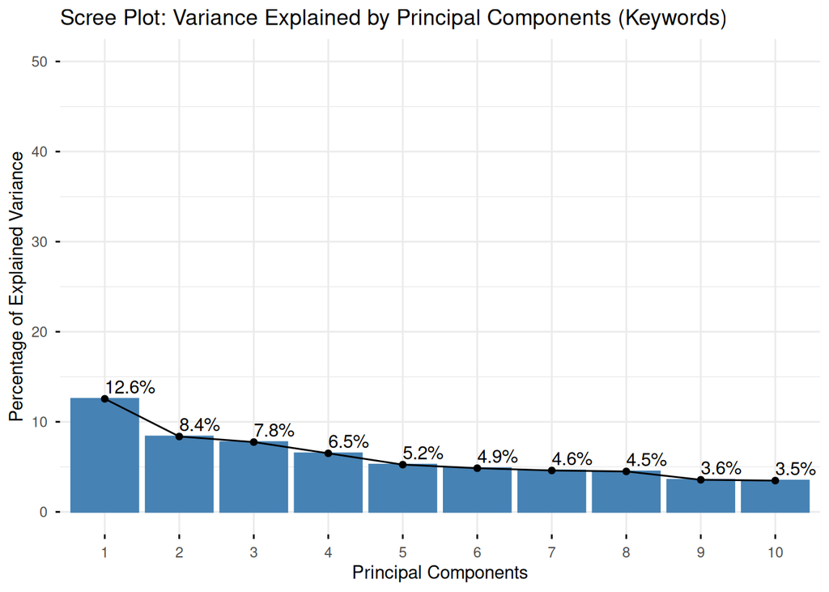

```r
# Scree plot
fviz_eig(pca_result_keywords,
         addlabels = TRUE,
         ylim = c(0, 50),
         main = "Scree Plot: Variance Explained by Principal Components (Keywords)",
         xlab = "Principal Components",
         ylab = "Percentage of Explained Variance")
```

The scree plot shows that the first few principal components explain a substantial portion of the variance, similar to the shape PCA.

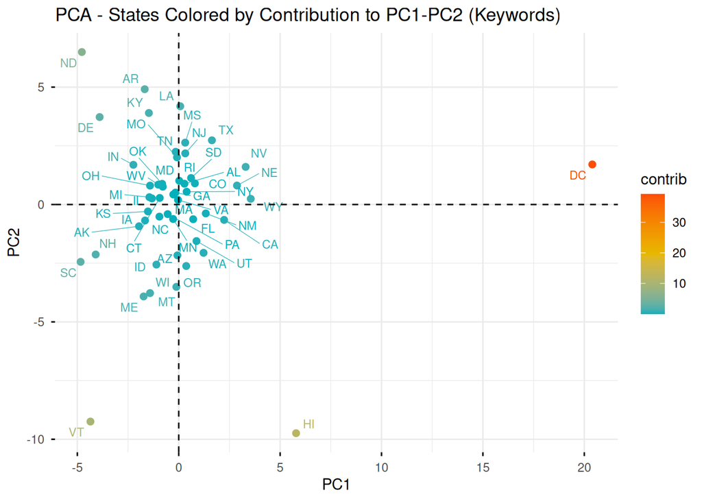

```r
# Scatterplot of states on PC1-PC2
fviz_pca_ind(pca_result_keywords,
             col.ind = "contrib",
             gradient.cols = c("#00AFBB", "#E7B800", "#FC4E07"),
             repel = TRUE,
             labelsize = 3,
             pointsize = 2,
             title = "PCA - States Colored by Contribution to PC1-PC2 (Keywords)",
             xlab = "PC1",
             ylab = "PC2")
```

Similar to the shape PCA, there may be no strong regional clusters, but outliers like DC, HI appear again if their keyword usage are unique. Other states could cluster based on similar descriptive language in reports.

```r
# Examine loadings for PC1 and PC2
loadings_keywords <- pca_result_keywords$rotation[, 1:2]
loadings_df_keywords <- as.data.frame(loadings_keywords)
loadings_df_keywords$word <- rownames(loadings_df_keywords)
```

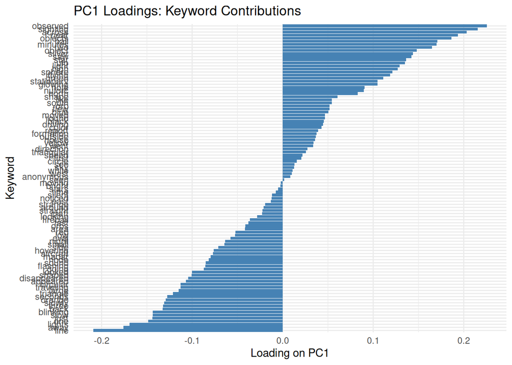

```r
# Bar plot for PC1 loadings
ggplot(loadings_df_keywords, aes(x = reorder(word, PC1), y = PC1)) +
  geom_bar(stat = "identity", fill = "steelblue") +
  coord_flip() +
  labs(title = "PC1 Loadings: Keyword Contributions",
       x = "Keyword",
       y = "Loading on PC1") +
  theme_minimal()
```

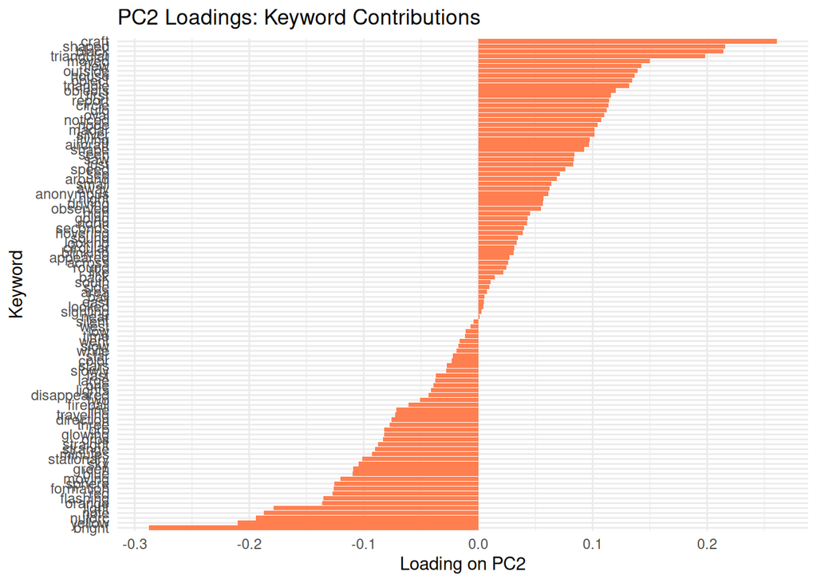

```r
# Bar plot for PC2 loadings
ggplot(loadings_df_keywords, aes(x = reorder(word, PC2), y = PC2)) +
  geom_bar(stat = "identity", fill = "coral") +
  coord_flip() +
  labs(title = "PC2 Loadings: Keyword Contributions",
       x = "Keyword",
       y = "Loading on PC2") +
  theme_minimal()
```

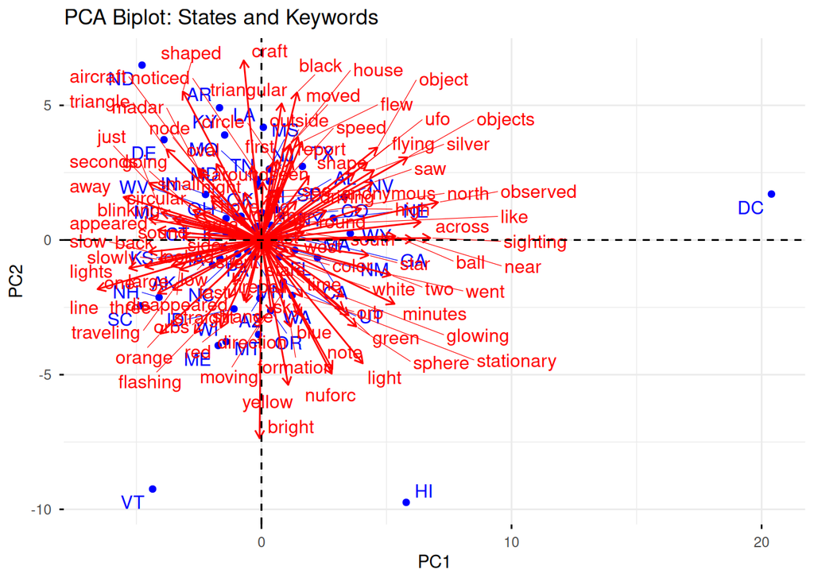

```r
# Biplot
fviz_pca_biplot(pca_result_keywords,
                repel = TRUE,
                col.var = "red",
                col.ind = "blue",
                title = "PCA Biplot: States and Keywords",
                xlab = "PC1",
                ylab = "PC2")
```

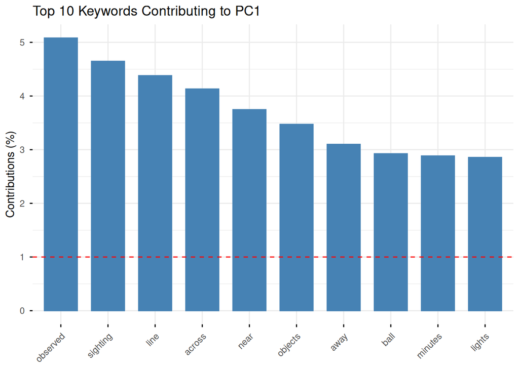

```r
# Top 10 contributing to PC1
fviz_contrib(pca_result_keywords, choice = "var", axes = 1, top = 10,
             title = "Top 10 Keywords Contributing to PC1")
```

Based on the fviz_contrib() bar plot, keywords contribute the most to PC1 are:obversed, sighting, line.

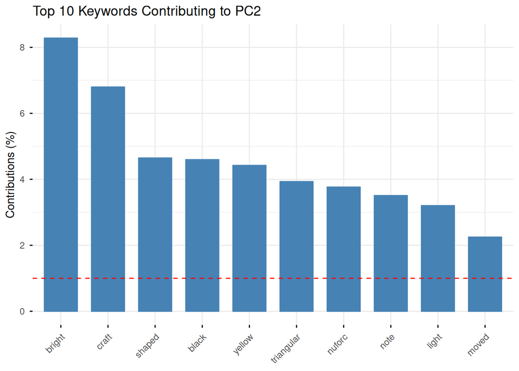

```r
# Top 10 contributing to PC2
fviz_contrib(pca_result_keywords, choice = "var", axes = 2, top = 10,
             title = "Top 10 Keywords Contributing to PC2")
```

Based on the fviz_contrib() bar plot, keywords contribute the most to PC2 are: bright, craft, shaped